# Tile charts

# When to use tile charts

Tile charts are great for ranking things over time or across categories, ex: ranking causes of death by year, causes of morbidity by age group, etc. They’re especially handy if you have a third, more broad category that you want to incorporate into your chart as you can use that category to color the tiles and look for more general trends.

In this example, we’re going to use the `AirPassengers` data set from the `datasets` package to look at which months had the most air traffic each year.

# R code

First load the packages you need.

```r
library(dplyr)
library(tidyr)
library(ggplot2)
library(ggtext)
library(grid)
library(gridExtra)
library(extrafont)
library(smcepi)
library(lubridate)
library(zoo)
```

We’re going to use the `AirPassengers` data from the `datasets` package. (To see all data in the datasets package, run `library(help = "datasets")`.)

We have to do a bit of wrangling here to convert the data frame a time series (`ts`) structure to a `2x2 data frame`.

```r
data <- AirPassengers

data1 <- data.frame(trips = as.matrix(data), date=as.Date(as.yearmon(time(data)))) %>%
  mutate(year = as.integer(year(date)),
         month = month(date, label = T, abbr = F),
         season = case_when(month(date) %in% 4:6 ~ "Spring",
                            month(date) %in% 7:9 ~ "Summer",
                            month(date) %in% 10:12 ~ "Fall",
                            TRUE ~ "Winter"))
```

We’ll start with a basic tile chart. We use `dplyr::group_by()` to rank the monthly number of air passengers from highest to lowest within each year. Then, we map each value using the `year` for the `x` value and the `rank` for the `y` value. We’re also using `season` to determine the color of each tile.

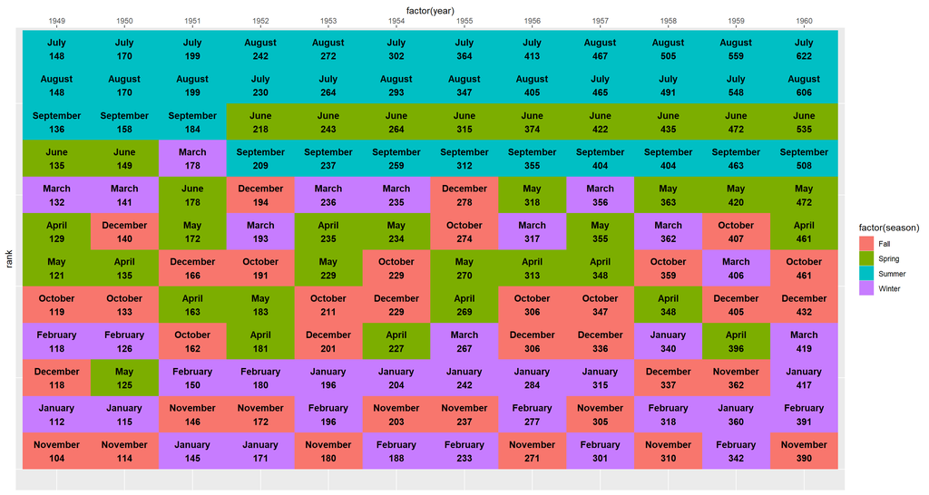

```r
plot1 <- data1 %>%
  group_by(year) %>%
  arrange(desc(trips)) %>%
  mutate(rank = row_number(),
         label = paste0(month, "\n", trips),
         year = as.factor(year)) %>%
  ungroup() %>%
  # plot by year and rank
  ggplot(aes(x = factor(year),
             y = rank)) +
  # fill tiles by season variable
  geom_tile(aes(fill = factor(season),
                height = 1)) +
  # add labels to each tile
  geom_text(aes(x = year,
                y = rank,
                label = label),
            color = "black",
            fontface = "bold",
            hjust = "center") +
  # flip chart so lower numbers are higher
  coord_trans(y = "reverse") +
  # get rid of extra whitespace
  coord_cartesian(ylim = c(12.5, 1)) +
  # move x axis label to the top
  scale_x_discrete(position = "top")
plot1
```

Now let’s make it look a little better. We’ll adjust the theme, add labels and change the colors of the groups.

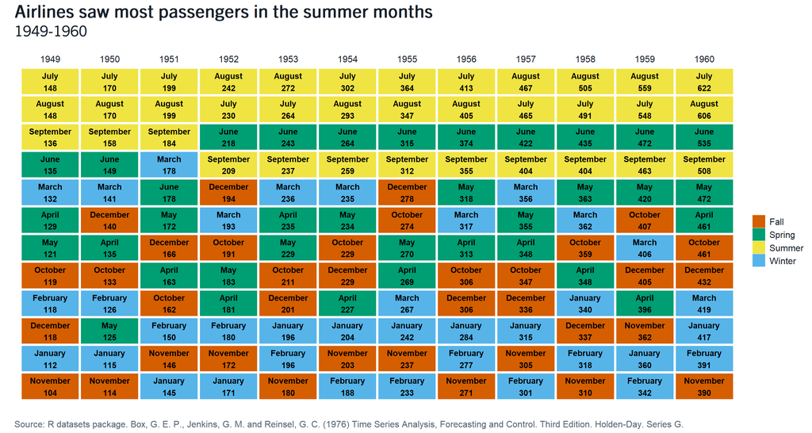

```r
# set up a color palette (this uses values from the Okabe Ito palette: https://siegal.bio.nyu.edu/color-palette/)
## note: the left values (spring, summer, fall and winter) are the values from the "season" variable that we used for "geom_tile(aes(fill = factor(season))"
pal <- c("Spring" = "#009E73", # green
         "Summer" = "#F0E442", # yellow
         "Fall" = "#D55E00", # orange
         "Winter" = "#56B4E9") # blue

plot2 <- plot1 +
  # apply our custom color palette instead of the default
  scale_fill_manual(values = pal) +
  # add a white border around each tile to make some visual space
  geom_tile(aes(width = 1,
                height = 1,
                y = rank),
            fill = NA,
            color = "white",
            size = 1.5) +
  # remove all plot lines, move legend to the right and adjust text sizes
  theme_gg_smc(plot_lines = "none",
               legend_loc = "right",
               axis_font_size = 12,
               title_font_size = 24,
               subtitle_font_size = 20,
               caption_font_size = 12) +
  # remove y-axis label ("rank")
  theme(axis.text.y = element_blank()) +
  # add labels
  labs(title = "Airlines saw most passengers in the summer months",
       subtitle = "1949-1960",
       caption = "Source: R datasets package. Box, G. E. P., Jenkins, G. M. and Reinsel, G. C. (1976) Time Series Analysis, Forecasting and Control. Third Edition. Holden-Day. Series G.",
       x = "",
       y = "")
plot2
```